# HW05

Shijie An

2022-10-04

```r
library(tidyverse)
```

1. Import the data using `read_csv()` and call it `acu`. Note that the data have a header row.

```r
acu <- read.csv("acupuncture.csv")
```

2. Use base R to calculate the mean and sd for each variable in the data set using `apply()`

```r
## mean for each element
apply(acu, MARGIN = 2, mean)
```

```
##            id           age           sex      migraine    chronicity
##   469.0066445    46.3388704     0.8405316     0.9435216    21.5980066
## acupuncturist         group           pk1           pk5
##     6.0299003     0.5348837    25.5689369    19.0824474
```

```r
## sd for each element
apply(acu, MARGIN = 2, sd)
```

```
##            id           age           sex      migraine    chronicity
##   204.4381894    10.3941386     0.3667220     0.2312276    13.9521036
## acupuncturist         group           pk1           pk5
##     2.7560424     0.4996123    15.4239810    15.6115822
```

3. Use the `by()` function to calculate the mean `pk5` score by treatment group. Are you comfortable making a conclusion about the efficacy of acupuncture based on these means? Why or why not?

```r
by(
  data = acu$pk5,
  INDICES = acu$group,
  FUN = mean
)
```

```
## acu$group: 0
## [1] 22.34345
## ------------------------------------------------------------
## acu$group: 1
## [1] 16.24679
```

```r
## It cannot be concluded about efficacy by only telling the relationship of group and severity of pk5. It needs more information other than groups.
```

4. Use base R to create a new variable called `diff` by calculating the difference score (post - pre) for headache severity rating.

```r
diff <- acu$pk5 - acu$pk1
acu <- mutate(acu, diff)
acu$diff
```

```
##   [1]  -0.66667   6.75000  -3.00000   8.75000   1.00000  -5.75000 -20.75000
##   [8] -12.00000 -11.75000   1.75000 -12.75000  -6.50000   0.50000  12.25000
##  [15] -29.75000  11.75000 -21.75000  -2.00000  -1.00000  -3.75000   6.50000
##  [22] -13.75000  -5.50000  -9.75000  -5.50000  -4.00000  -4.75000  -9.75000
##  [29]   5.50000 -16.00000 -44.75000  28.73334 -15.50000 -20.00000  -0.50000
##  [36]  -7.50000 -34.50000 -10.25000   4.00000 -14.75000  -7.50000  -8.25000
##  [43] -36.00000 -27.50000 -16.00000 -10.75000  -5.00000 -31.00000  -7.75000
##  [50]   5.00000  -5.50000  -6.25000 -10.00000  -1.25000 -11.25000   0.00000
##  [57]  12.25000  -4.50000   2.25000 -18.00000  -6.00000 -16.75000   6.50000
##  [64] -36.75000   1.75000  -3.50000  -8.75000  -5.75000 -11.75000   5.00000
##  [71] -15.25000 -10.25000  -9.75000 -12.25000 -18.00000   1.75000  -8.00000
##  [78] -22.75000   7.50000  -6.50000 -10.00000  -9.50000 -11.75000 -11.00000
##  [85] -12.25000  -4.00000   3.25000   8.25000  -3.00000   2.75000   5.25000
##  [92] -11.75000   5.00000  10.50000   3.75000 -12.50000   4.50000 -10.25000
##  [99]  -4.75000 -25.00000 -17.50000  12.75000  -0.75000 -15.25000 -16.00000
```

[output cut: 28 more lines]

5. Use base R to create a new variable called `remission` that is a 1 if a person’s score dropped by 10 points or more and a 0 if not.

```r
acu <- mutate(acu, remission <- ifelse(diff <= -10, 1, 0))
acu$remission
```

```
##   [1] 0 0 0 0 0 0 1 1 1 0 1 0 0 0 1 0 1 0 0 0 0 1 0 0 0 0 0 0 0 1 1 0 1 1 0 0 1
##  [38] 1 0 1 0 0 1 1 1 1 0 1 0 0 0 0 1 0 1 0 0 0 0 1 0 1 0 1 0 0 0 0 1 0 1 1 0 1
##  [75] 1 0 0 1 0 0 1 0 1 1 1 0 0 0 0 0 0 1 0 0 0 1 0 1 0 1 1 0 0 1 1 0 0 1 0 0 0
## [112] 1 0 0 0 0 0 0 0 0 0 1 0 0 1 0 0 1 0 0 0 1 0 1 1 0 0 0 0 0 0 0 0 0 0 0 0 0
## [149] 0 0 0 1 0 0 0 1 0 1 1 0 1 0 0 0 0 1 0 1 0 0 1 0 0 1 0 1 0 1 0 0 0 0 0 0 1
## [186] 1 1 0 0 0 1 0 1 1 0 0 0 0 1 0 1 0 0 0 0 0 0 0 0 0 0 0 1 1 0 0 1 1 0 0 0 0
## [223] 0 0 0 1 0 0 0 0 0 1 1 0 1 1 1 0 1 0 0 0 1 0 1 0 0 0 1 1 1 0 1 1 0 0 0 0 0
## [260] 1 1 0 1 0 0 0 0 0 1 0 0 0 1 0 0 0 0 0 1 0 0 0 0 0 1 0 0 0 0 1 0 0 1 1 0 0
## [297] 1 0 1 1 0
```

6. Use tidyverse functions to replicate (3) - (5), calling the variables `diff2` and `remission2`

```r
acu %>%
  group_by(group) %>%
  summarize(mean(pk5))
```

```
## # A tibble: 2 × 2
##   group `mean(pk5)`
##   <int>       <dbl>
## 1     0        22.3
## 2     1        16.2
```

```r
acu <- acu %>%
  mutate(diff2 = pk5 - pk1)
acu$diff2
```

```
##   [1]  -0.66667   6.75000  -3.00000   8.75000   1.00000  -5.75000 -20.75000
##   [8] -12.00000 -11.75000   1.75000 -12.75000  -6.50000   0.50000  12.25000
##  [15] -29.75000  11.75000 -21.75000  -2.00000  -1.00000  -3.75000   6.50000
##  [22] -13.75000  -5.50000  -9.75000  -5.50000  -4.00000  -4.75000  -9.75000
##  [29]   5.50000 -16.00000 -44.75000  28.73334 -15.50000 -20.00000  -0.50000
##  [36]  -7.50000 -34.50000 -10.25000   4.00000 -14.75000  -7.50000  -8.25000
##  [43] -36.00000 -27.50000 -16.00000 -10.75000  -5.00000 -31.00000  -7.75000
##  [50]   5.00000  -5.50000  -6.25000 -10.00000  -1.25000 -11.25000   0.00000
##  [57]  12.25000  -4.50000   2.25000 -18.00000  -6.00000 -16.75000   6.50000
##  [64] -36.75000   1.75000  -3.50000  -8.75000  -5.75000 -11.75000   5.00000
##  [71] -15.25000 -10.25000  -9.75000 -12.25000 -18.00000   1.75000  -8.00000
##  [78] -22.75000   7.50000  -6.50000 -10.00000  -9.50000 -11.75000 -11.00000
##  [85] -12.25000  -4.00000   3.25000   8.25000  -3.00000   2.75000   5.25000
##  [92] -11.75000   5.00000  10.50000   3.75000 -12.50000   4.50000 -10.25000
##  [99]  -4.75000 -25.00000 -17.50000  12.75000  -0.75000 -15.25000 -16.00000
```

[output cut: 28 more lines]

```r
acu <- acu %>%
  mutate(remission2 = ifelse(diff2 <= -10, 1, 0))
acu$remission2
```

```
##   [1] 0 0 0 0 0 0 1 1 1 0 1 0 0 0 1 0 1 0 0 0 0 1 0 0 0 0 0 0 0 1 1 0 1 1 0 0 1
##  [38] 1 0 1 0 0 1 1 1 1 0 1 0 0 0 0 1 0 1 0 0 0 0 1 0 1 0 1 0 0 0 0 1 0 1 1 0 1
##  [75] 1 0 0 1 0 0 1 0 1 1 1 0 0 0 0 0 0 1 0 0 0 1 0 1 0 1 1 0 0 1 1 0 0 1 0 0 0
## [112] 1 0 0 0 0 0 0 0 0 0 1 0 0 1 0 0 1 0 0 0 1 0 1 1 0 0 0 0 0 0 0 0 0 0 0 0 0
## [149] 0 0 0 1 0 0 0 1 0 1 1 0 1 0 0 0 0 1 0 1 0 0 1 0 0 1 0 1 0 1 0 0 0 0 0 0 1
## [186] 1 1 0 0 0 1 0 1 1 0 0 0 0 1 0 1 0 0 0 0 0 0 0 0 0 0 0 1 1 0 0 1 1 0 0 0 0
## [223] 0 0 0 1 0 0 0 0 0 1 1 0 1 1 1 0 1 0 0 0 1 0 1 0 0 0 1 1 1 0 1 1 0 0 0 0 0
## [260] 1 1 0 1 0 0 0 0 0 1 0 0 0 1 0 0 0 0 0 1 0 0 0 0 0 1 0 0 0 0 1 0 0 1 1 0 0
## [297] 1 0 1 1 0
```

7. Create a scatterplot of baseline headache severity rating (horizontal axis) vs 1-year headache severity rating (vertical axis) using base R.

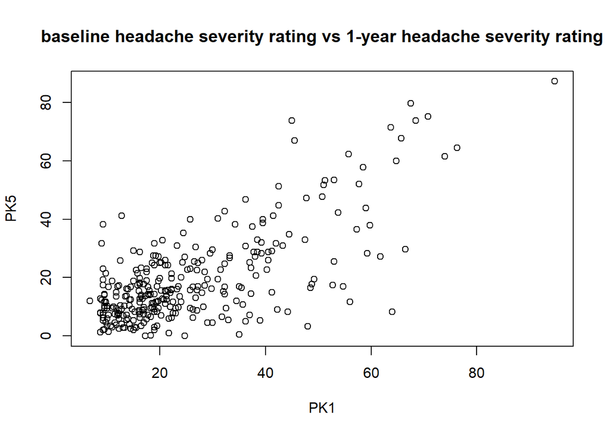

```r
plot(acu$pk1, acu$pk5, xlab = "PK1", ylab = "PK5",
     main = "baseline headache severity rating vs 1-year headache severity rating")
```

8. Use `ggplot2`to replicate (7).

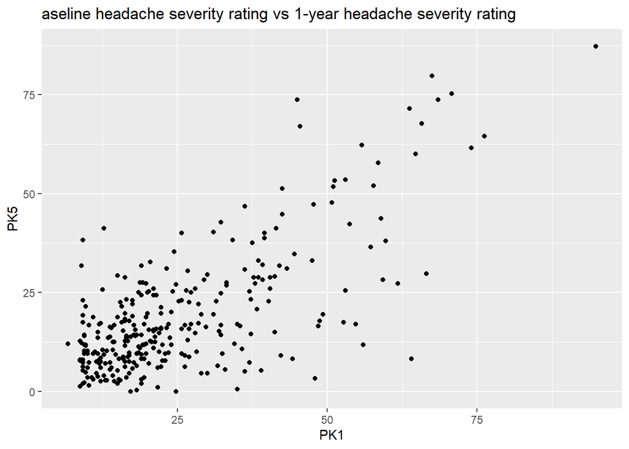

```r
acu %>%
  ggplot(aes(x = pk1, y = pk5)) +
  geom_point() +
  xlab("PK1") +
  ylab("PK5") +
  ggtitle("aseline headache severity rating vs 1-year headache severity rating")
```

9. In either base R or ggplot2, take your pick, incorporate information on treatment group and sex into the plot. Consider using color, point character, point size, or other graphical elements. Be sure to include a legend.

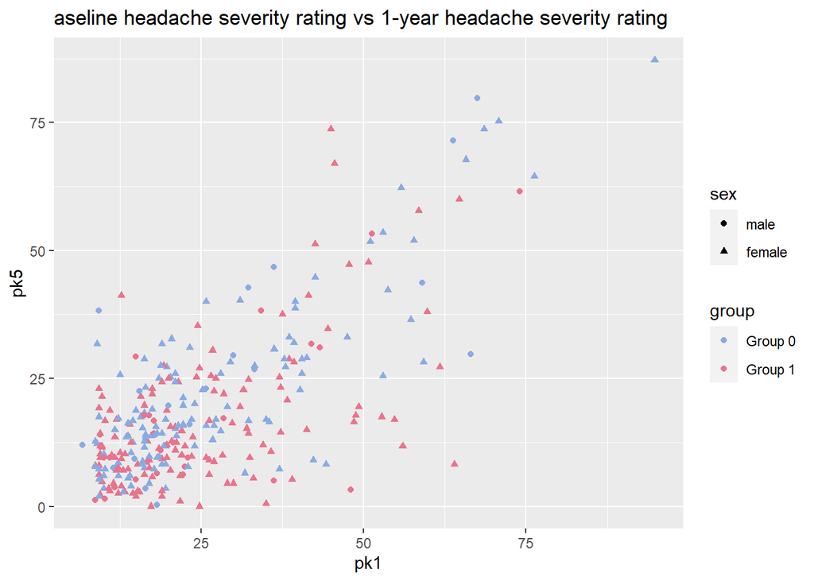

```r
acu %>%
  mutate(group = factor(x = group,
                           labels = c("Group 0", "Group 1"),
                           levels = c(0, 1)),
            sex = factor(x = sex,
                         labels = c("male", "female"),
                         levels = c(0, 1))) %>%
  ggplot(aes(x = pk1, y = pk5, color = group, shape = sex))  +
  geom_point() +
  scale_color_manual(values = c("#89ABE3FF", "#EA738DFF")) +
  ggtitle("aseline headache severity rating vs 1-year headache severity rating")
```

10. Try to replicate what you did in (9) with the other plotting platform. I.e., if you used base R, now try to replicate using ggplot (or vice versa)

[figure not shown]

```r
plot(acu$pk1~ acu$pk5, xlab = "PK1", ylab = "PK5",
     col = factor(acu$sex),
     pch = acu$group,
     main = "baseline headache severity rating vs 1-year headache severity rating")
legend(
  x = "bottomright",
  legend = c("Group 0", "Group 1", "male", "female"),
  title = "Group and Sex",
  col = c("red", "black", "black", "black"),
  pch = c(16, 16, 1, 0)
)
```